# Tarea5_AlejandroBarrantes

Alejandro Barrantes Castro

2023-04-19

# EJERCICIO #1

```r
setwd("~/ALEJANDRO/1er Ciclo 2023/Mineria de Datos/Tarea 4/DatosTarea")
Datos <- read.table("EjemploAlgoritmosRecomendacion.csv", header=TRUE, sep=';',dec=',',row.names=1)
```

## a) Ejecute el metodo k−medias con iter.max = 200, nstart = 100 para k = 4, luego desde RStudio verifique el Teorema de Fisher para este ejemplo

```r
mis.datos <- scale(Datos)
grupos <- kmeans(x = mis.datos, centers = 4, iter.max = 200, nstart = 100)

# Verificación del Teorema de Fisher
grupos$totss==grupos$tot.withinss+grupos$betweenss
```

```
## [1] TRUE
```

## b) Ejecute el metodo k−medias con iter.max = 200, nstart = 100 , para esto encuentre valor de k usando los metodos Gap Statistic, wss y Average Silhouette usando la funcion fviz nbclust, luego interprete los resultados usando interpretacion Horizontal-Vertical y graficos tipo radar plot.

### Gap-Statistic:

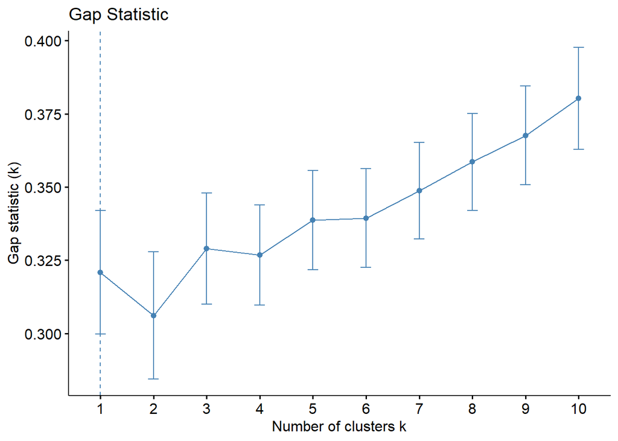

```r
fviz_nbclust(mis.datos, kmeans, method = "gap_stat", nstart = 100, iter.max = 200) +
  ggtitle("Gap Statistic")
```

[figure not shown]

```r
grupos<-kmeans(mis.datos,centers=1,iter.max=200,nstart=100)
# Centros
centros<-grupos$centers
# Gráfico Tipo Araña
rownames(centros)<-c("Cluster 1")
centros<-as.data.frame(centros)
maximos<-apply(centros,2,max)
minimos<-apply(centros,2,min)
centros<-rbind(minimos,centros)
centros<-rbind(maximos,centros)

radarchart(as.data.frame(centros),maxmin=TRUE,axistype=4,axislabcol="slategray4",
           centerzero=FALSE,seg=8, cglcol="gray67",
           pcol=color,plty=1,plwd=5,title="Comparación de clústeres")
legenda <-legend(1.5,1, legend=c("Cluster 1","Cluster 2"),
                 seg.len=-1.4,title="Clústeres",pch=21,bty="n" ,lwd=3, y.intersp=1,
                 horiz=FALSE,col=color)
```

[figure not shown]

```r
# Grafico de barras
barplot(t(grupos$centers),beside=TRUE,legend=colnames(Datos),main = "Gráfico de Interpretación de Clases",col=color2,ylim=c(-1,4),cex.names = 0.7)
```

[output not shown]

### WSS:

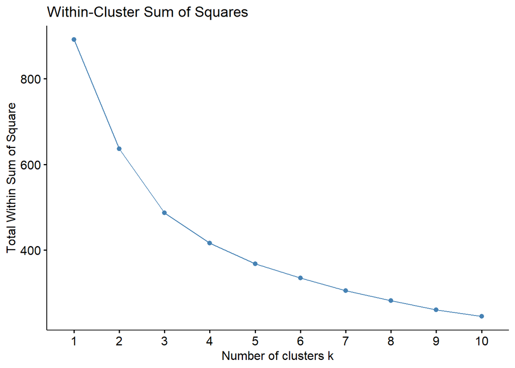

```r
fviz_nbclust(mis.datos, kmeans, method = "wss", nstart = 100, iter.max = 200) +
  ggtitle("Within-Cluster Sum of Squares")
```

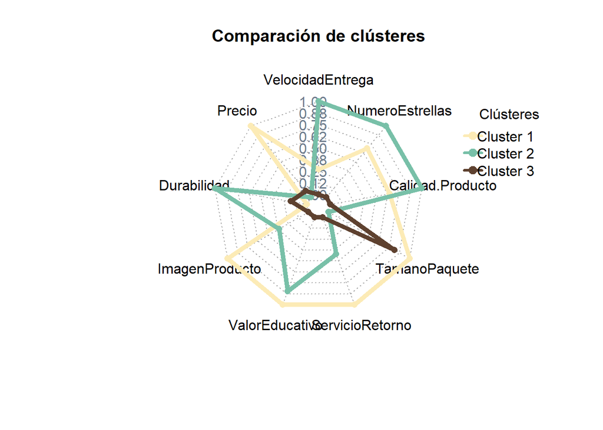

```r
#asociar a los emtodos de arriba
# Sacando Grupos
grupos<-kmeans(mis.datos,centers=3,iter.max=200,nstart=100)
# Centros
centros<-grupos$centers
# Gráfico Tipo Araña
rownames(centros)<-c("Cluster 1","Cluster 2","Cluster 3")
centros<-as.data.frame(centros)
maximos<-apply(centros,2,max)
minimos<-apply(centros,2,min)
centros<-rbind(minimos,centros)
centros<-rbind(maximos,centros)

color <- c("#FCEBB6","#78C0A8","#5E412F")
radarchart(as.data.frame(centros),maxmin=TRUE,axistype=4,axislabcol="slategray4",
           centerzero=FALSE,seg=8, cglcol="gray67",
           pcol=color,plty=1,plwd=5,title="Comparación de clústeres")
legenda <-legend(1.5,1, legend=c("Cluster 1","Cluster 2","Cluster 3"),
                 seg.len=-1.4,title="Clústeres",pch=21,bty="n" ,lwd=3, y.intersp=1,
                 horiz=FALSE,col=color)
```

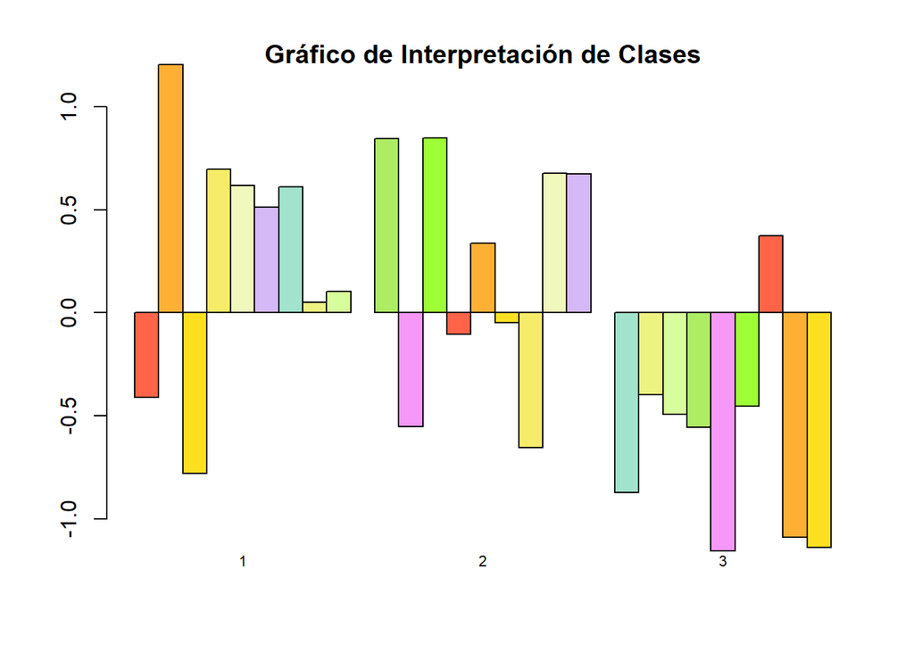

```r
# Grafico de barras
barplot(t(grupos$centers),beside=TRUE,main = "Gráfico de Interpretación de Clases",col=color2,ylim=c(-1,1),cex.names = 0.7)
```

### Silhouette:

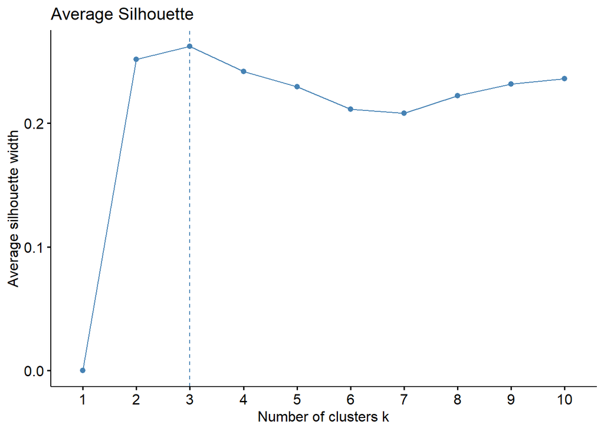

```r
fviz_nbclust(mis.datos, kmeans, method = "silhouette", nstart = 100, iter.max = 200) +
  ggtitle("Average Silhouette")
```

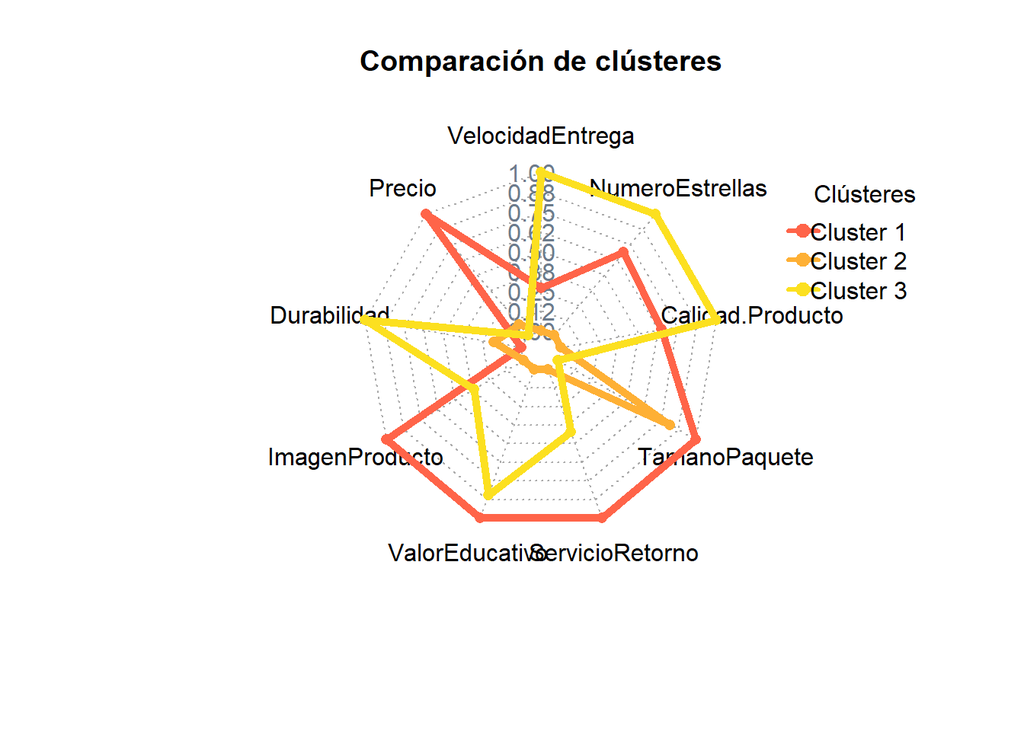

```r
# Sacando Grupos
grupos<-kmeans(mis.datos,centers=3,iter.max=200,nstart=100)
# Centros
centros<-grupos$centers
# Gráfico Tipo Araña
rownames(centros)<-c("Cluster 1","Cluster 2","Cluster 3")
centros<-as.data.frame(centros)
maximos<-apply(centros,2,max)
minimos<-apply(centros,2,min)
centros<-rbind(minimos,centros)
centros<-rbind(maximos,centros)

radarchart(as.data.frame(centros),maxmin=TRUE,axistype=4,axislabcol="slategray4",
           centerzero=FALSE,seg=8, cglcol="gray67",
           pcol=color2,plty=1,plwd=5,title="Comparación de clústeres")
legenda <-legend(1.5,1, legend=c("Cluster 1","Cluster 2","Cluster 3"),
                 seg.len=-1.4,title="Clústeres",pch=21,bty="n" ,lwd=3, y.intersp=1,
                 horiz=FALSE,col=color2)
```

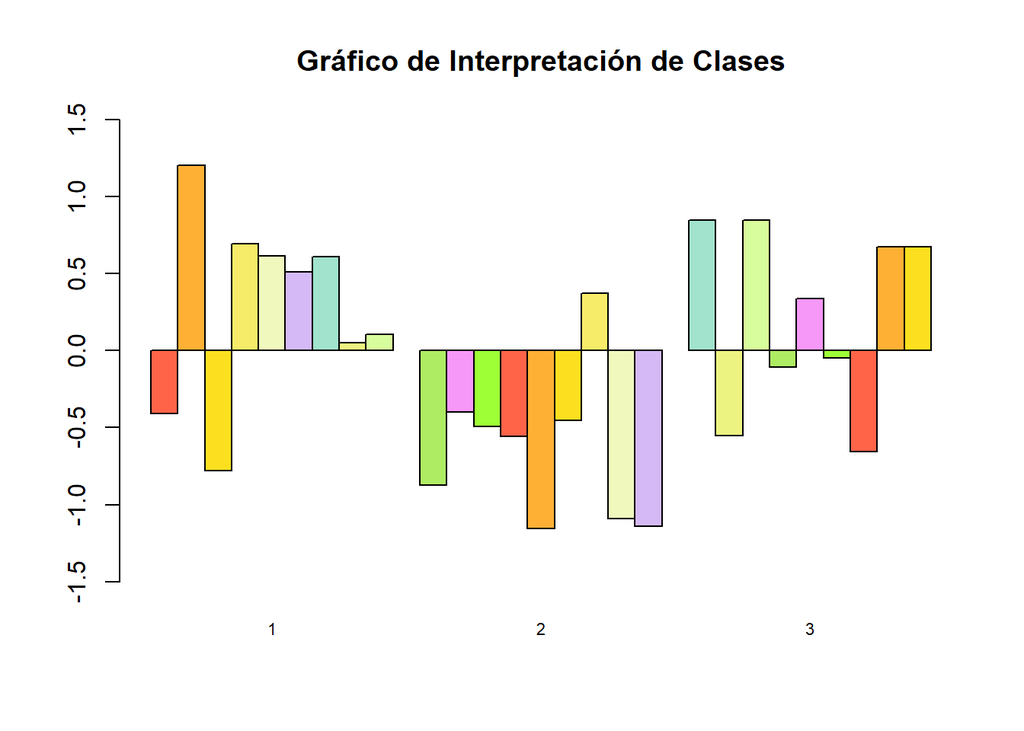

```r
# Grafico de barras
barplot(t(grupos$centers),beside=TRUE,main = "Gráfico de Interpretación de Clases",col=color2,ylim=c(-1.5,1.5),cex.names = 0.7)
```

## c) Si se tienen 7 clusteres usando usando el metodo de k-medias ¿Que productos recomendarıa a Teresa, a Leo y a Justin?, es decir, ¿los productos que compra cual otro cliente? Usando distancia euclıdea ¿cual es la mejor recomendacion de compra que le podemos hacer a Teresa, a Leo y a Justin?

```r
grupos<-kmeans(mis.datos,centers=7,iter.max=200,nstart=100)
str(Datos)
```

```
## 'data.frame':    100 obs. of  9 variables:
##  $ VelocidadEntrega: num  2.05 0.9 1.7 1.35 3 0.95 2.3 0.65 2.75 2 ...
##  $ Precio          : num  0.3 1.5 2.6 0.5 0.45 1.65 1.2 2.1 0.8 1.75 ...
##  $ Durabilidad     : num  3.45 3.15 2.85 3.55 4.8 3.95 4.75 3.1 4.7 3.25 ...
##  $ ImagenProducto  : num  2.35 3.3 3 2.95 3.9 2.4 3.3 2.55 2.35 3 ...
##  $ ValorEducativo  : num  2.4 2.5 4.3 1.8 3.4 2.6 3.5 2.8 3.5 3.7 ...
##  $ ServicioRetorno : num  2.3 4 2.7 2.3 4.6 1.9 4.5 2.2 3 3.2 ...
##  $ TamanoPaquete   : num  2.6 4.2 4.1 3.9 2.25 4.85 3.8 3.45 3.8 4.35 ...
##  $ Calidad.Producto: num  2.1 2.15 2.6 1.95 3.4 2.2 2.9 2.15 2.7 2.7 ...
##  $ NumeroEstrellas : num  1.7 2.8 3.3 1.7 4.3 3 3.1 2.9 4.8 3.9 ...
```

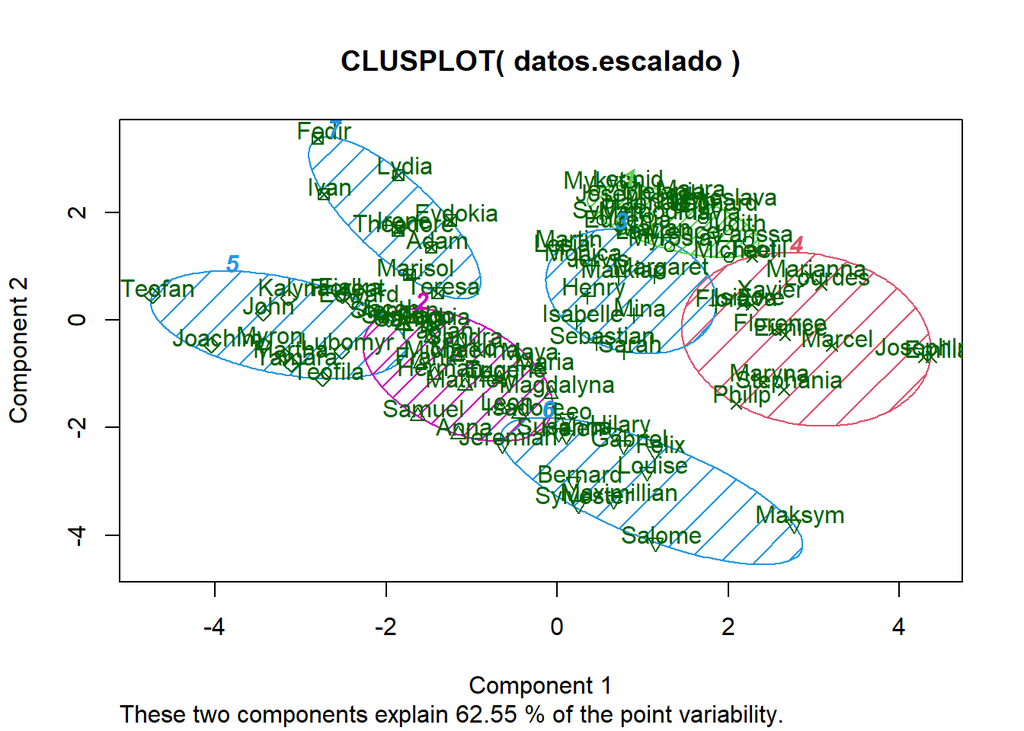

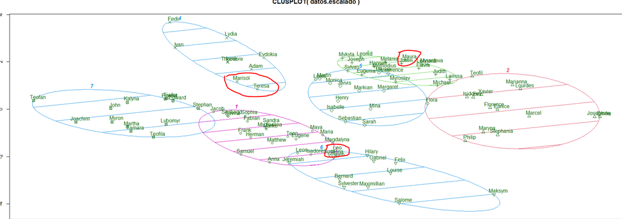

7 Clusteres!

```r
datos.escalado <- data.frame(scale(Datos), grupos$cluster)
clusplot(datos.escalado, grupos$cluster, color=TRUE, shade=TRUE,
         labels=2, lines=0)
```

### Como se puede observar en la imagen, para Teresa yo le recomendaria las productos que compra cualquier otro cliente del cluster en el que ella se encuentra. La mejor recomendacion para Teresa utilizando distancia euclidea es la de Marisol.

### Para Leo yo le recomendaria las productos que compra cualquier otro cliente del cluster en el que el se encuentra. La mejor recomendacion para Leo utilizando distancia euclidea es la de Susana, ya que es la mas cercana

### Para Justin yo le recomendaria las productos que compra cualquier otro cliente del cluster en el que el se encuentra. La mejor recomendacion para Justin utilizando distancia euclidea es la de Maura, ya que es la mas cercana a el en el grafico

# Ejercicio #2

## a) Cargue la tabla de datos y ejecute un str(…), summary(…) y un dim(…), verifique la correcta lectura de los datos.

```r
setwd("~/ALEJANDRO/1er Ciclo 2023/Mineria de Datos/Tarea 5")
Datos <- read.csv('DatosBeijing.csv', header=TRUE, sep=',',dec='.',row.names=1)
str(Datos)
```

```
## 'data.frame':    43824 obs. of  12 variables:
##  $ Anno                       : int  2010 2010 2010 2010 2010 2010 2010 2010 2010 2010 ...
##  $ Mes                        : int  1 1 1 1 1 1 1 1 1 1 ...
##  $ Dia                        : int  1 1 1 1 1 1 1 1 1 1 ...
##  $ Hora                       : int  0 1 2 3 4 5 6 7 8 9 ...
##  $ ConcetracionParticula_pm2.5: int  NA NA NA NA NA NA NA NA NA NA ...
##  $ PuntoRocio                 : int  -21 -21 -21 -21 -20 -19 -19 -19 -19 -20 ...
##  $ Temperatura                : num  -11 -12 -11 -14 -12 -10 -9 -9 -9 -8 ...
##  $ Presion                    : num  1021 1020 1019 1019 1018 ...
##  $ DireccionViento            : chr  "NW" "NW" "NW" "NW" ...
##  $ VelocidadViento            : num  1.79 4.92 6.71 9.84 12.97 ...
##  $ HorasNieve                 : int  0 0 0 0 0 0 0 0 0 0 ...
##  $ HorasLluvia                : int  0 0 0 0 0 0 0 0 0 0 ...
```

```r
summary(Datos)
```

```
##       Anno           Mes              Dia             Hora
##  Min.   :2010   Min.   : 1.000   Min.   : 1.00   Min.   : 0.00
##  1st Qu.:2011   1st Qu.: 4.000   1st Qu.: 8.00   1st Qu.: 5.75
##  Median :2012   Median : 7.000   Median :16.00   Median :11.50
##  Mean   :2012   Mean   : 6.524   Mean   :15.73   Mean   :11.50
##  3rd Qu.:2013   3rd Qu.:10.000   3rd Qu.:23.00   3rd Qu.:17.25
##  Max.   :2014   Max.   :12.000   Max.   :31.00   Max.   :23.00
##
##  ConcetracionParticula_pm2.5   PuntoRocio       Temperatura        Presion
##  Min.   :  0.00              Min.   :-40.000   Min.   :-19.00   Min.   : 991
##  1st Qu.: 29.00              1st Qu.:-10.000   1st Qu.:  2.00   1st Qu.:1008
##  Median : 72.00              Median :  2.000   Median : 14.00   Median :1016
##  Mean   : 98.61              Mean   :  1.817   Mean   : 12.45   Mean   :1016
##  3rd Qu.:137.00              3rd Qu.: 15.000   3rd Qu.: 23.00   3rd Qu.:1025
##  Max.   :994.00              Max.   : 28.000   Max.   : 42.00   Max.   :1046
##  NA's   :2067
##  DireccionViento    VelocidadViento    HorasNieve        HorasLluvia
##  Length:43824       Min.   :  0.45   Min.   : 0.00000   Min.   : 0.0000
##  Class :character   1st Qu.:  1.79   1st Qu.: 0.00000   1st Qu.: 0.0000
##  Mode  :character   Median :  5.37   Median : 0.00000   Median : 0.0000
##                     Mean   : 23.89   Mean   : 0.05273   Mean   : 0.1949
##                     3rd Qu.: 21.91   3rd Qu.: 0.00000   3rd Qu.: 0.0000
##                     Max.   :585.60   Max.   :27.00000   Max.   :36.0000
##
```

```r
dim(Datos)
```

```
## [1] 43824    12
```

### b) Elimine las filas con NA usando el comando na.omit(…). ¿Cuantas filas de eliminaron?

```r
Datos.sin.na<-na.omit(Datos)
```

### Se eliminaron:

```r
nrow(Datos)-nrow(Datos.sin.na)
```

```
## [1] 2067
```

## c) Elimine de la tabla de datos la variable DireccionViento. ¿Por que se debe eliminar?

```r
Datos.sin.na <- subset(Datos.sin.na, select = -DireccionViento)
```

### se debe eliminar debido a que es de tipo cualitativa y la otra alternativa seria convertirla a tipo factor por niveles, a tipo daisy.

```r
#modelo <- hclust(dist(Datos.sin.na),method = "complete")
#modelo
```

## f ) De una interpretacion de los resultados usando un grafico tipo radar.

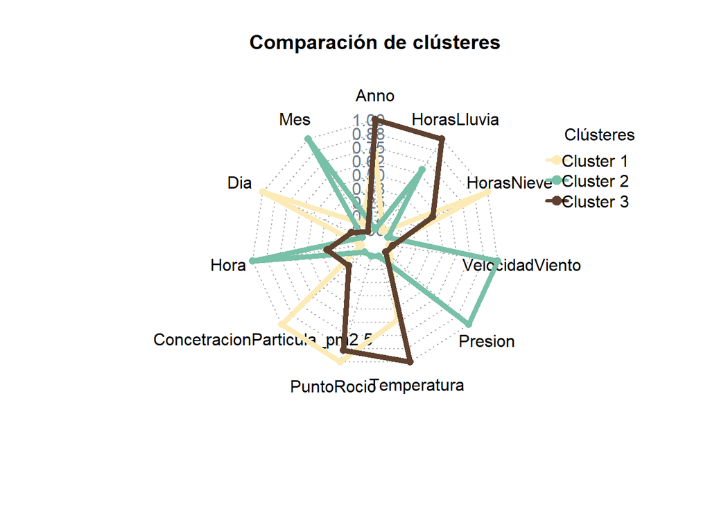

```r
grupos<-kmeans(Datos.sin.na,centers=3,iter.max=100, nstart=50)
centros<-grupos$centers
rownames(centros)<-c("Cluster 1","Cluster 2","Cluster 3")
centros<-as.data.frame(centros)
maximos<-apply(centros,2,max)
minimos<-apply(centros,2,min)
centros<-rbind(minimos,centros)
centros<-rbind(maximos,centros)

color <- c("#FCEBB6","#78C0A8","#5E412F")

radarchart(as.data.frame(centros),maxmin=TRUE,axistype=4,axislabcol="slategray4",
           centerzero=FALSE,seg=8, cglcol="gray67",
           pcol=color,plty=1,plwd=5,title="Comparación de clústeres")

legenda <-legend(1.5,1, legend=c("Cluster 1","Cluster 2","Cluster 3"),
                 seg.len=-1.4,title="Clústeres",pch=21,bty="n" ,lwd=3, y.intersp=1,   horiz=FALSE,col=color)
```

## g) Construya el Codo de Jambu usando iter.max=100 y nstart=5, ¿cuantos conglomerados (clusteres) sugiere el codo?

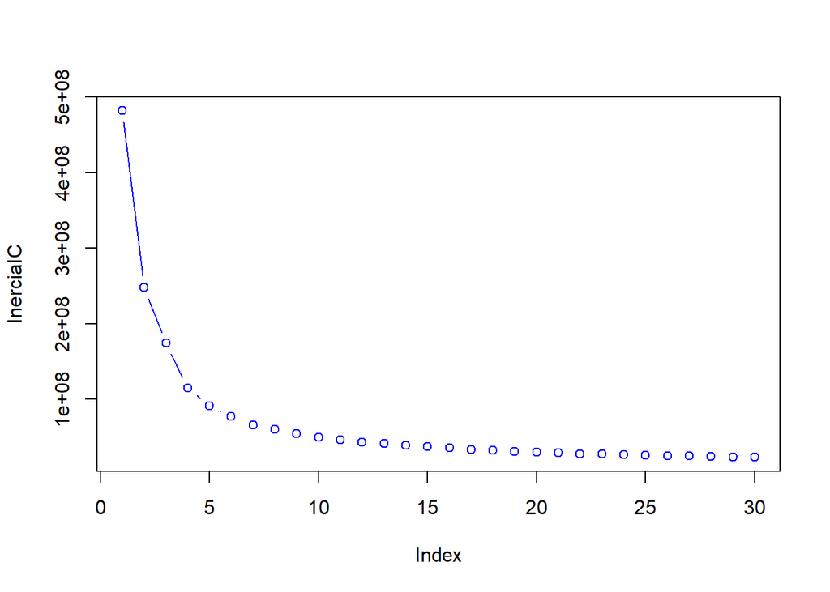

```r
centers <- matrix(c(0,3,1,3,0,4), 3, 2, byrow=T)
generate <- function(n=50, extradim=0, sigma=1, mu=7) {
  data1 <- matrix(rnorm(n*2), n, 2) * sigma
  data1[,1] <- data1[,1] + centers[1,1] * mu
  data1[,2] <- data1[,2] + centers[1,2] * mu
  data2 <- matrix(rnorm(n*2), n, 2) * sigma
  data2[,1] <- data2[,1] + centers[2,1] * mu
  data2[,2] <- data2[,2] + centers[2,2] * mu
  data3 <- matrix(rnorm(n*2), n, 2) * sigma
  data3[,1] <- data3[,1] + centers[3,1] * mu
  data3[,2] <- data3[,2] + centers[3,2] * mu
  data <- rbind(data1,data2,data3)
  if (extradim > 0) {
    noise <- matrix(rnorm(3*n*extradim)*sigma, 3*n, extradim)
    data <- cbind(data, noise)
  }
  return(data)
}

#Datos.sin.na <- generate(extradim=0)
InerciaIC<-rep(0,30)
suppressWarnings(for(k in 1:30) {
  grupos<-kmeans(Datos.sin.na,centers=k,iter.max = 100,nstart=5)
  InerciaIC[k]<-grupos$tot.withinss
})
suppressWarnings(plot(InerciaIC,col="blue",type="b"))
```

### Viendo el grafico, se sugieren aproximadamente 3 clusteres para los datos

## Utilice tambien el metodo silhouette de la funcion fviz nbclust, ¿cuantos conglomerados (clusteres) sugiere este metodo?

### Utilizare 10mil filas, ya que al usar todas, excede la memoria ram de mi pc

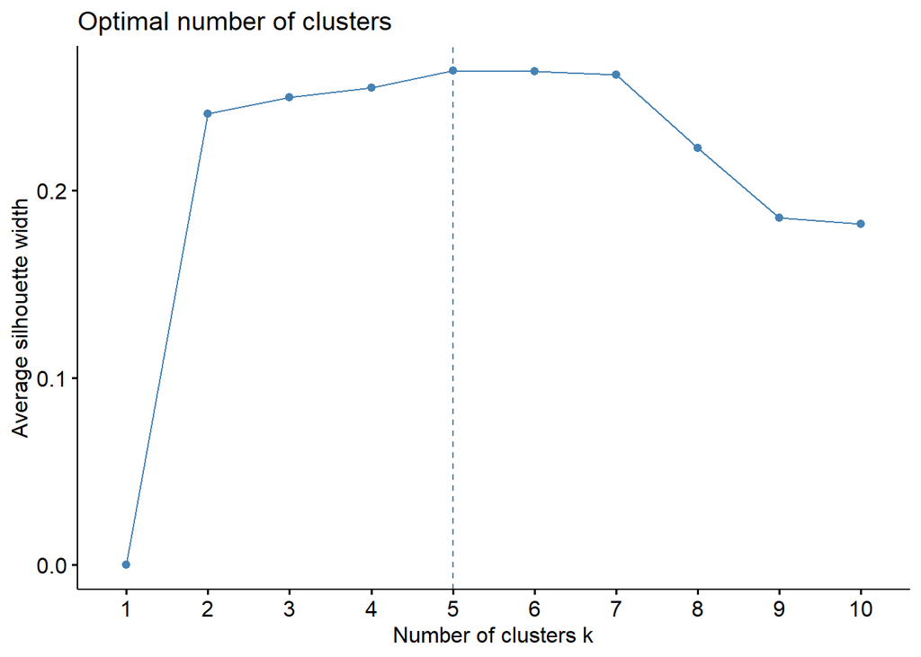

```r
mis.datos <- scale(Datos.sin.na)
suppressWarnings(fviz_nbclust(mis.datos[1:10000,], kmeans, method = "silhouette",nstart = 100, iter.max = 5))
```